# Weissensee results exploration 2014-2016

## Introduction

One of my hobbies is ice-skating and in 2015 I have done the “Alternatieve Elfstedentocht” for the first time. It is an ice skating event held in Austria, over a distance of 200km ([video](https://www.youtube.com/watch?v=FhdifsMYr8s)). In a period of about 10 days multiple events are held, for professionals as well as for amateurs.

Most participants are from the Netherlands, they are so unfortunate that there is not enough ice on their lakes to organise such an event. Because I was interested in how many people finished the 200km and what the average finish time was, I have done some data analysis. First I have scraped the data from the Weissensee website to a csv file, with a python script. Notice: these results are only from the amateur 200km races that are held in the years mentioned above.

## Dataset info

```
## 'data.frame':    9697 obs. of  10 variables:
##  $ EventId : int  220103 220103 220103 220103 220103 220103 220103 220103 220103 220103 ...
##  $ Date    : Factor w/ 10 levels "19-1-2016","22-1-2016",..: 4 4 4 4 4 4 4 4 4 4 ...
##  $ Id      : int  3952 3792 3815 3817 3131 3906 3774 3002 3350 3132 ...
##  $ Name    : Factor w/ 6628 levels " ","Aad de Haas",..: 1895 5362 5974 189 4172 5533 1945 4830 2118 1942 ...
##  $ Country : Factor w/ 21 levels ""," AUT"," BEL",..: 14 14 14 14 14 14 14 14 14 14 ...
##  $ City    : Factor w/ 1442 levels "","-","1E EXLOERMOND",..: 565 583 565 565 683 583 565 1215 1202 45 ...
##  $ Laps    : int  16 16 16 16 16 16 16 16 16 16 ...
##  $ Distance: num  200 200 200 200 200 200 200 200 200 200 ...
##  $ Time    : Factor w/ 7509 levels "0:58:29","10:00:02",..: 3874 3874 3875 3876 3915 4028 4258 4270 4279 4282 ...
##  $ Speed   : Factor w/ 1453 levels "10.06 km/h","10.10 km/h",..: 1453 1453 1453 1453 1453 1453 1453 1453 1453 1453 ...
```

### Finish times (200km)

The event is held at a lake where the participants skate some amount of laps to complete the 200km distance. Mostly a lap is between 10 and 25km, depending on the ice conditions. A larger lap size is supposed to lead to a faster finish time, because bigger groups can form, so there is less air resistance. Also corners slow down. The plot above shows the finish times of all the events. It follows a normal distribution quite well.

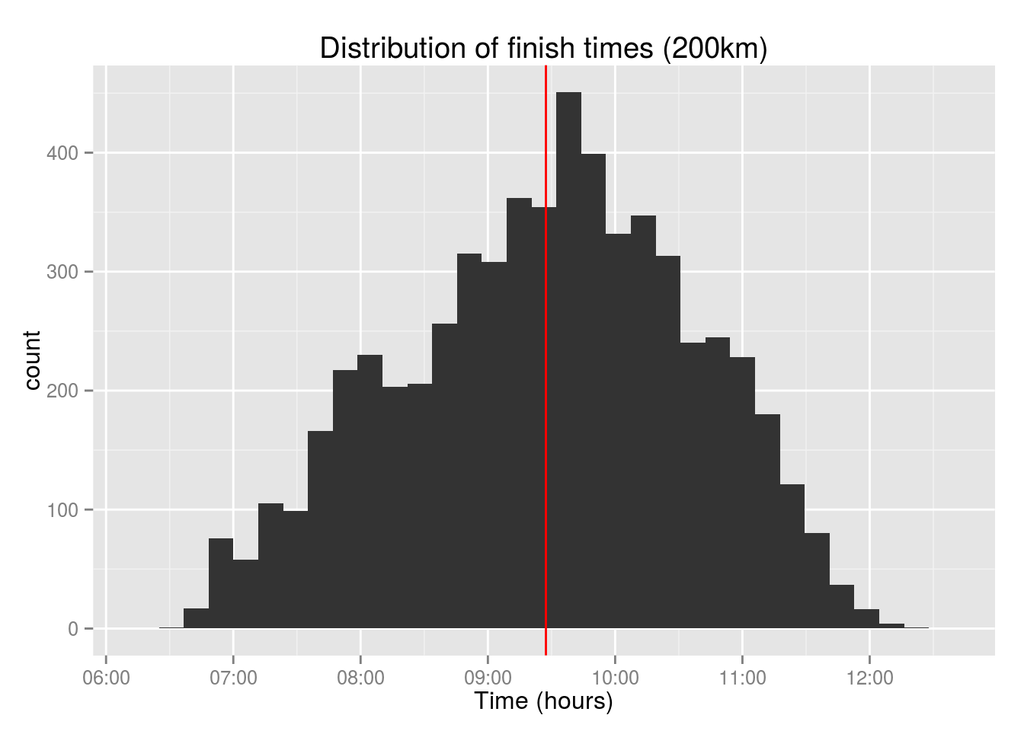

```
## [1] "Average: 09:27:21, standard deviation: 01:08:43"
```

### Finish times (200km) per year

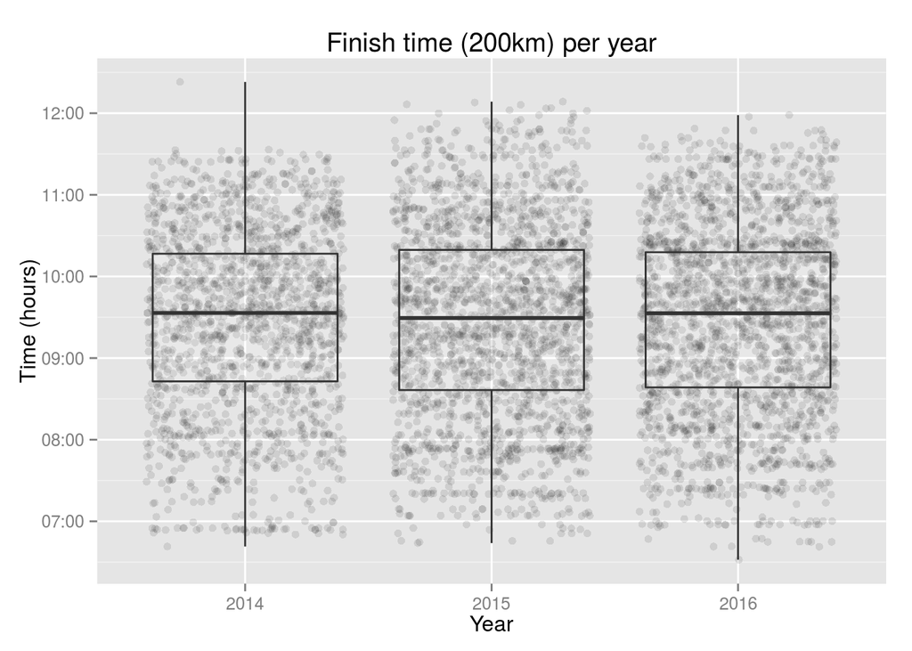

```
##   Year Average finish time
## 1 2014            09:27:23
## 2 2015            09:27:10
## 3 2016            09:27:30
```

### Participants count

The histogram displays the number of participants per event. Below that the average and total participants per year are given. For the last years, the number of participants are increasing! In 2016 this is probably (partly) caused by the fact that there are 4 events held instead of 3 in the years before.

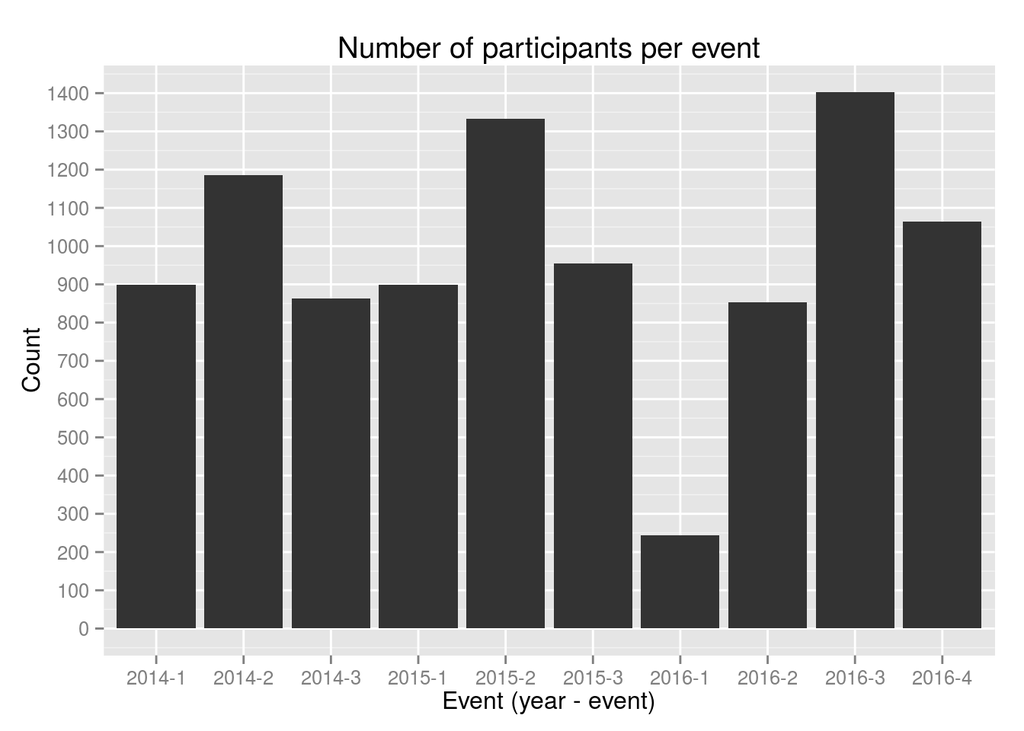

```
##  year average total
##  2014  982.00  2946
##  2015 1062.00  3186
##  2016  891.25  3565
```

### Participants country of residence

Well, I guess the histogram says it all, you can call this a Dutch event!

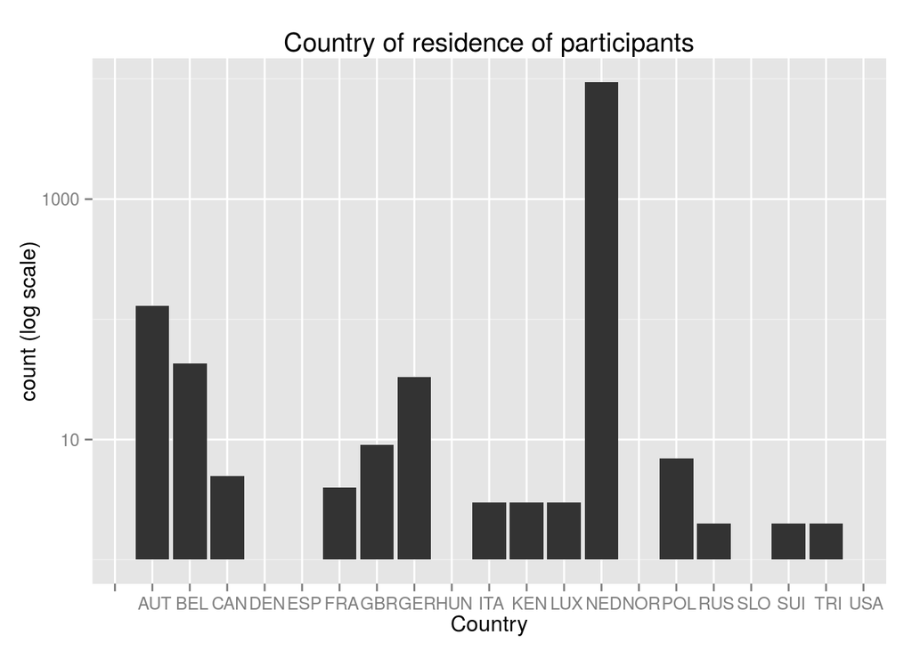

```
##       AUT  BEL  CAN  DEN  ESP  FRA  GBR  GER  HUN  ITA  KEN  LUX  NED  NOR
##    1  129   43    5    1    1    4    9   33    1    3    3    3 9445    1
##  POL  RUS  SLO  SUI  TRI  USA
##    7    2    1    2    2    1
```

### Completed distance

Not all people can finish the 200km distance, because of various reasons: crashes, bad material, bad condition, etc. Fortunately, one can skate a shorter distance: simply skate less laps. The histogram shows that most people can finish the 200km, 100km is the next best.

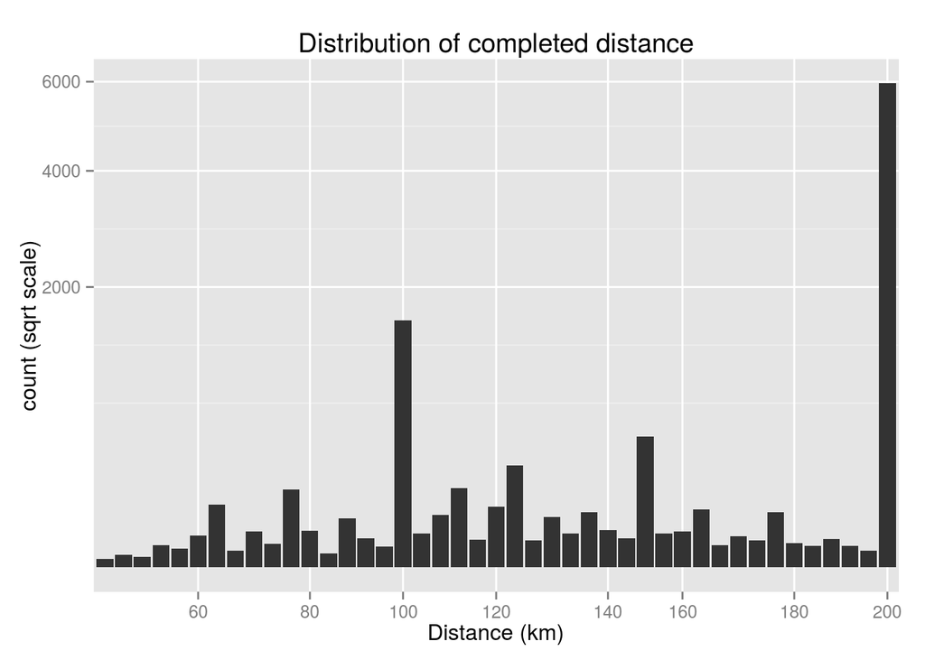

```
##    Min. 1st Qu.  Median    Mean 3rd Qu.    Max.
##   18.18  120.00  200.00  167.00  200.00  200.00
```

## Weissensee to the max

Some participants just can’t get enough of ice-skating and are participating multiple times in the event. The event is held 3 or 4 times in a period of 10 days and I am curious who finished all 3 or 4 times in the full distance and what their times were.

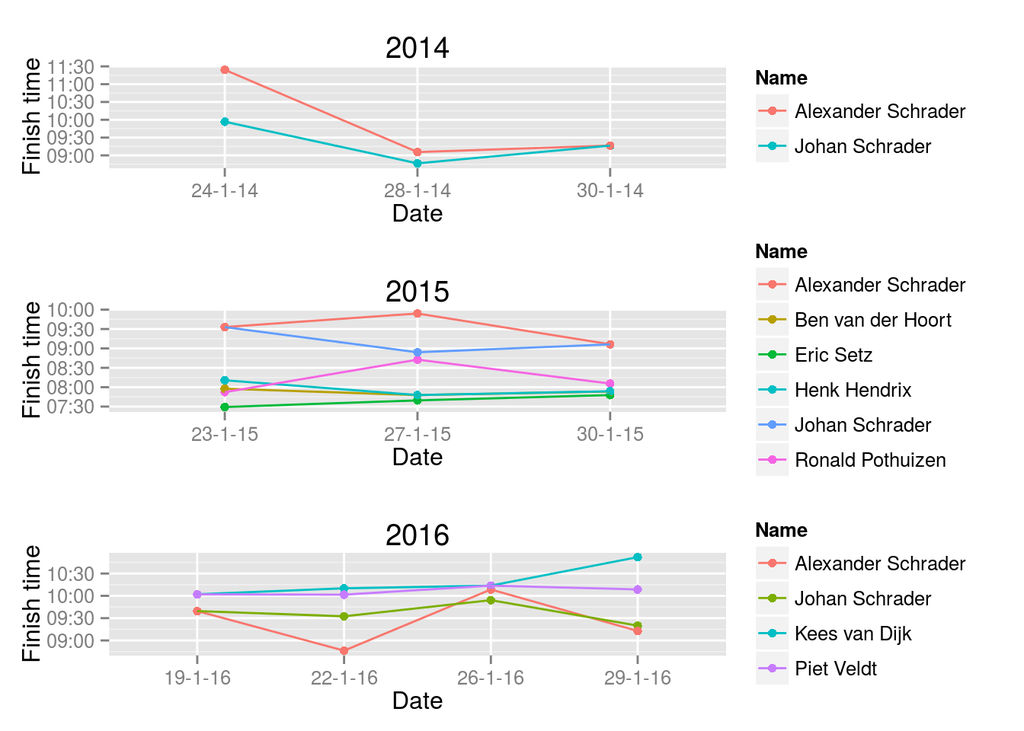

## Ideas for future work

- relate finish times to weather conditions (wind, snow conditions, temperature)
- relate finish times to lap size
- add results of other years and look for trends